# A1

Me

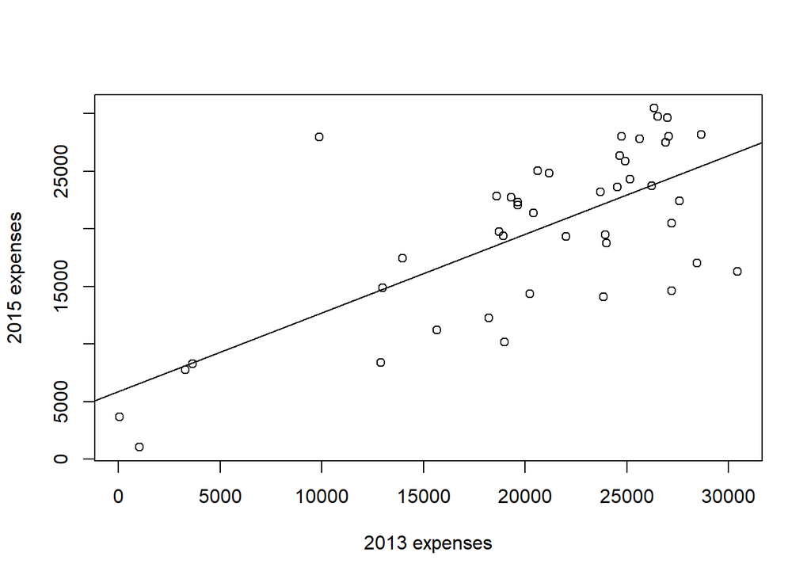

```r
#read in data in A1.csv and assign it to mydata
mydata <- read.csv("A1.csv",sep=";")
#fit a linear model with proper labels
fit <- lm(X2015.expenses ~ X2013.expenses, data = mydata)
plot(mydata$X2013.expenses, mydata$X2015.expenses,
      xlab = "2013 expenses", ylab = "2015 expenses")
#add the line of best fit to the plot
abline(fit)
```

```r
#get the summary of linear model fit, it provides estimates of intercept and slope.
summary(fit)
```

```
##
## Call:
## lm(formula = X2015.expenses ~ X2013.expenses, data = mydata)
##
## Residuals:
##    Min     1Q Median     3Q    Max
## -10379  -3640   1050   3633  15370
##
## Coefficients:
##                 Estimate Std. Error t value Pr(>|t|)
## (Intercept)    5855.1183  2334.5168   2.508   0.0161 *
## X2013.expenses    0.6841     0.1067   6.410 1.02e-07 ***
## ---
## Signif. codes:  0 '***' 0.001 '**' 0.01 '*' 0.05 '.' 0.1 ' ' 1
##
## Residual standard error: 5286 on 42 degrees of freedom
## Multiple R-squared:  0.4945, Adjusted R-squared:  0.4825
## F-statistic: 41.09 on 1 and 42 DF,  p-value: 1.02e-07
```

From the r output above i can tell that estimate of intercept is 5855, and that of the slope is 0.6841. So the equation for line of best fit is
$$\begin{align}
\hat{y_i} = 5855 + 0.6841x
\end{align}$$
For the intercept:
$$\begin{align}
H_0: \beta_0 = 0\\
H_1: \beta_0 \neq 0\\
\end{align}$$

From the r output above i can tell p-value for the intercept is 0.0161, which is less than 0.05. So i can reject H_0 in favour of H_1 at 0.05 significance level, and the intercept is statistically significent at 0.05 significance level.

For the slope:
$$\begin{align}
H_0: \beta_1 = 0\\
H_1: \beta_1 \neq 0\\
\end{align}$$

From the r output above i can tell p-value for the slope is 1.02e-07, which is less than 0.05. So i can reject H_0 in favour of H_1 at 0.05 significance level, and the slope is statistically significent at 0.05 significance level.

```r
# added 0 term to force the line of best fit to go through the origin
fit2 <- lm(mydata$X2015.expenses ~ 0 + mydata$X2013.expenses)
#get the summary of the new linear model fit2
summary(fit2)
```

```
##
## Call:
## lm(formula = mydata$X2015.expenses ~ 0 + mydata$X2013.expenses)
##
## Residuals:
##    Min     1Q Median     3Q    Max
## -12181  -3430   2258   4353  18737
##
## Coefficients:
##                       Estimate Std. Error t value Pr(>|t|)
## mydata$X2013.expenses   0.9357     0.0386   24.24   <2e-16 ***
## ---
## Signif. codes:  0 '***' 0.001 '**' 0.01 '*' 0.05 '.' 0.1 ' ' 1
##
## Residual standard error: 5601 on 43 degrees of freedom
## Multiple R-squared:  0.9318, Adjusted R-squared:  0.9302
## F-statistic: 587.5 on 1 and 43 DF,  p-value: < 2.2e-16
```

```r
#getting the 95% confidence interval of the slope.
confint(fit2, 'mydata$X2013.expenses', level=0.95)
```

```
##                           2.5 %   97.5 %
## mydata$X2013.expenses 0.8578103 1.013506
```

From the r output above i can tell that the 95% confidence interval of the slope is between 0.8578 and 1.014. So there is a 95% chance that the interval between 0.8578 and 1.014 contains the true value of slope. The rate of inflation from 2013 to 2015 is 0.017*(1+0.017) = 0.01729. Since 0.01729 is not in the 95% confidence interval, i am 95% confident that councillors’ net expenses did not change in step with inflation from 2013 to 2015.

# Q4

```r
#new.X2013.expense is the data frame contains $18,986.47 as x*
new.X2013.expense <- data.frame(
  X2013.expenses = c(18986.47)
)
#using the default 95% confidence level to get the prediction interval of y* given x* equals 18986.47, using linear model called fit from Q2.
predict(fit, new.X2013.expense, interval="predict")
```

```
##        fit      lwr      upr
## 1 18843.34 8050.607 29636.07
```

```r
#From the r output above, y-hat* is 18843.34.
y_hat_star<- 18843.34
#lwr is assigned the lower bound of the 95% confidence interval, which is 8050.607 from the r output above
lwr<-8050.607

#working with t distribution since the population standard deviation is unknown.

#degree of freedom = 44 - 2 = 42
#assign the t value with 0.05 significance level and 42 degree of freedom to t_0.025_42
t_0.025_42<- qt(0.975, 42)

#i can now calculate standard error, explanation is provided in the picture below
stderror <- (y_hat_star - lwr) / (t_0.025_42)
#standardise 35000 and assign it to t_score
t_score<- (35000 - y_hat_star) / stderror
#Pr(y > 35000) = 1 - Pr(0 <= y <= 35000)
prob <- (1 - pt(t_score, 42))
print(prob)
```

[output not shown]

```
## [1] 0.002138014
```

From the r output above:
$$\begin{align}
\text{Pr(y > 35000) = 0.0021}
\end{align}$$

So the probability that a mayor would spend more than $35,000 in 2015 is approximately 0.0021.

```r
newdata <- mydata[-sample(1:nrow(mydata), 19), ]
#print(data.new)
#fit3 <- lm(newdata$X2015.expenses ~ newdata$X2013.expenses)
```

Question 6: I worked with Wenyue Feng, Student # 1003443455, Utorid: fengwen8